# ノートブックの概要

EDA及び、前処理がちゃんと動きそうかの確認のためのノートブック。以下のことを行っている

- データ読み込んでみる
- 時系列データを可視化
- 時間軸をどこで区切るべきか（年？年度？）
- 緩やかな変動を捉える（prophet）
  - トレンドとの残差を確認
- 引っ越し件数が0の部分（＝休業日と判明）
- clientフラグについて
- 料金区分（午前、午後）
  - 料金区分（price_am, price_pm）が3以上のものを詳しく見てみる
- 数値変換を試す

# ライブラリのインポート

```python
import polars as pl
import polars.selectors as cs
pl.Config.set_tbl_cols(100)
pl.Config.set_tbl_width_chars(200)

import numpy as np
from scipy import stats

import matplotlib.pyplot as plt
%matplotlib inline
import japanize_matplotlib

import seaborn as sns

import plotly
plotly.offline.init_notebook_mode()  # github pages 対応
import plotly.express as px
import plotly.graph_objects as go
from plotly.subplots import make_subplots

from datetime import date
import matplotlib.dates as mdates

import jpholiday

from prophet import Prophet
```

# データ読み込んでみる

```python
train = pl.read_csv("../data/input/train.csv")
test = pl.read_csv("../data/input/test.csv")
sample_submit = pl.read_csv("../data/output/sample_submit.csv", has_header=False)

print("train\n", train)
print("test\n", test)
print("sample_submit\n", sample_submit)
```

```
train
 shape: (2_101, 6)
┌────────────┬─────┬────────┬───────┬──────────┬──────────┐
│ datetime   ┆ y   ┆ client ┆ close ┆ price_am ┆ price_pm │
│ ---        ┆ --- ┆ ---    ┆ ---   ┆ ---      ┆ ---      │
│ str        ┆ i64 ┆ i64    ┆ i64   ┆ i64      ┆ i64      │
╞════════════╪═════╪════════╪═══════╪══════════╪══════════╡
│ 2010-07-01 ┆ 17  ┆ 0      ┆ 0     ┆ -1       ┆ -1       │
│ 2010-07-02 ┆ 18  ┆ 0      ┆ 0     ┆ -1       ┆ -1       │
│ 2010-07-03 ┆ 20  ┆ 0      ┆ 0     ┆ -1       ┆ -1       │
│ 2010-07-04 ┆ 20  ┆ 0      ┆ 0     ┆ -1       ┆ -1       │
│ 2010-07-05 ┆ 14  ┆ 0      ┆ 0     ┆ -1       ┆ -1       │
│ …          ┆ …   ┆ …      ┆ …     ┆ …        ┆ …        │
│ 2016-03-27 ┆ 94  ┆ 1      ┆ 0     ┆ 5        ┆ 4        │
│ 2016-03-28 ┆ 86  ┆ 1      ┆ 0     ┆ 4        ┆ 4        │
│ 2016-03-29 ┆ 98  ┆ 1      ┆ 0     ┆ 4        ┆ 4        │
│ 2016-03-30 ┆ 99  ┆ 1      ┆ 0     ┆ 5        ┆ 4        │
│ 2016-03-31 ┆ 105 ┆ 1      ┆ 0     ┆ 5        ┆ 4        │
└────────────┴─────┴────────┴───────┴──────────┴──────────┘
test
 shape: (365, 5)
┌────────────┬────────┬───────┬──────────┬──────────┐
│ datetime   ┆ client ┆ close ┆ price_am ┆ price_pm │
│ ---        ┆ ---    ┆ ---   ┆ ---      ┆ ---      │
│ str        ┆ i64    ┆ i64   ┆ i64      ┆ i64      │
╞════════════╪════════╪═══════╪══════════╪══════════╡
│ 2016-04-01 ┆ 1      ┆ 0     ┆ 3        ┆ 2        │
│ 2016-04-02 ┆ 0      ┆ 0     ┆ 5        ┆ 5        │
│ 2016-04-03 ┆ 1      ┆ 0     ┆ 2        ┆ 2        │
│ 2016-04-04 ┆ 1      ┆ 0     ┆ 1        ┆ 1        │
│ 2016-04-05 ┆ 0      ┆ 0     ┆ 1        ┆ 1        │
│ …          ┆ …      ┆ …     ┆ …        ┆ …        │
│ 2017-03-27 ┆ 0      ┆ 0     ┆ 5        ┆ 4        │
│ 2017-03-28 ┆ 0      ┆ 0     ┆ 4        ┆ 4        │
│ 2017-03-29 ┆ 0      ┆ 0     ┆ 3        ┆ 3        │
│ 2017-03-30 ┆ 0      ┆ 0     ┆ 4        ┆ 3        │
│ 2017-03-31 ┆ 1      ┆ 0     ┆ 5        ┆ 4        │
└────────────┴────────┴───────┴──────────┴──────────┘
sample_submit
 shape: (365, 2)
┌────────────┬───────────┐
│ column_1   ┆ column_2  │
│ ---        ┆ ---       │
│ str        ┆ f64       │
╞════════════╪═══════════╡
│ 2016-04-01 ┆ 65.989206 │
│ 2016-04-02 ┆ 73.07633  │
│ 2016-04-03 ┆ 62.837857 │
│ 2016-04-04 ┆ 57.607645 │
│ 2016-04-05 ┆ 56.316084 │
│ …          ┆ …         │
│ 2017-03-27 ┆ 95.172858 │
│ 2017-03-28 ┆ 95.172858 │
│ 2017-03-29 ┆ 95.172858 │
│ 2017-03-30 ┆ 95.172858 │
│ 2017-03-31 ┆ 95.172858 │
└────────────┴───────────┘
```

データの読み方について

```python
# IDとして使用されているdatetimeカラムを文字列型と日付型に分離
# カラムの役割を分散することでコードエラーを発生しにくくする
train = train.insert_column(0, train["datetime"].alias("id")).with_columns(
    pl.col("datetime").str.strptime(dtype=pl.Date)
)
test = test.insert_column(0, test["datetime"].alias("id")).with_columns(
    pl.col("datetime").str.strptime(dtype=pl.Date)
)

print(train.head())
```

```
shape: (5, 7)
┌────────────┬────────────┬─────┬────────┬───────┬──────────┬──────────┐
│ id         ┆ datetime   ┆ y   ┆ client ┆ close ┆ price_am ┆ price_pm │
│ ---        ┆ ---        ┆ --- ┆ ---    ┆ ---   ┆ ---      ┆ ---      │
│ str        ┆ date       ┆ i64 ┆ i64    ┆ i64   ┆ i64      ┆ i64      │
╞════════════╪════════════╪═════╪════════╪═══════╪══════════╪══════════╡
│ 2010-07-01 ┆ 2010-07-01 ┆ 17  ┆ 0      ┆ 0     ┆ -1       ┆ -1       │
│ 2010-07-02 ┆ 2010-07-02 ┆ 18  ┆ 0      ┆ 0     ┆ -1       ┆ -1       │
│ 2010-07-03 ┆ 2010-07-03 ┆ 20  ┆ 0      ┆ 0     ┆ -1       ┆ -1       │
│ 2010-07-04 ┆ 2010-07-04 ┆ 20  ┆ 0      ┆ 0     ┆ -1       ┆ -1       │
│ 2010-07-05 ┆ 2010-07-05 ┆ 14  ┆ 0      ┆ 0     ┆ -1       ┆ -1       │
└────────────┴────────────┴─────┴────────┴───────┴──────────┴──────────┘
```

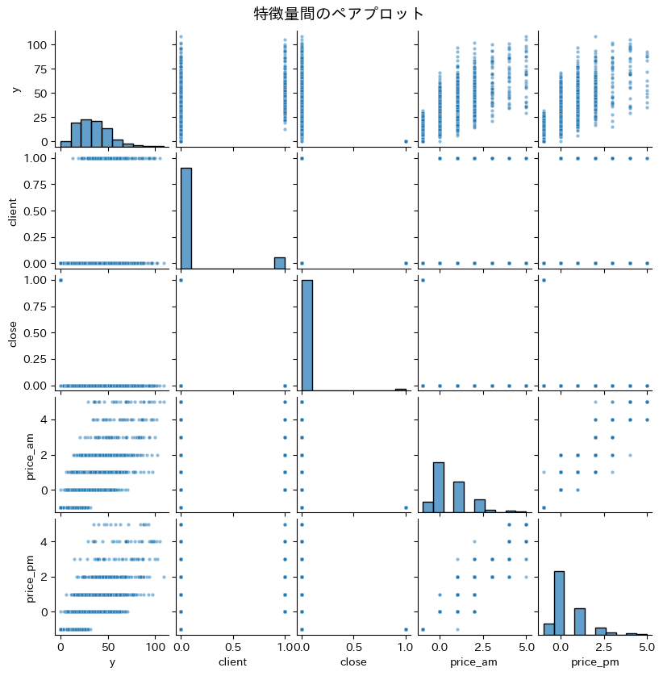

```python
# 訓練データの散布図行列
g = sns.pairplot(
    train.select(cs.exclude("id")).to_pandas(),
    plot_kws={"alpha": 0.5, "s": 10},
    diag_kws={"alpha": 0.7, "bins": 10},
)
g.figure.set_size_inches(8, 8)
g.figure.suptitle("特徴量間のペアプロット", y=1.02, fontsize=14)
plt.show()
```

# 時系列データを可視化

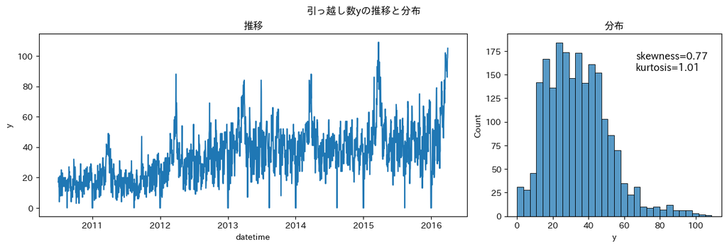

```python
# 歪度と尖度を計算
skew = stats.skew(train["y"])
kurt = stats.kurtosis(train["y"])

# 可視化
fig, axes = plt.subplots(
    nrows=1,
    ncols=2,
    height_ratios=[1],
    width_ratios=[2, 1],
    figsize=(12, 4),
    constrained_layout=True,
)
fig.suptitle("引っ越し数yの推移と分布")

axes[0].set_title("推移")
sns.lineplot(data=train, x="datetime", y="y", ax=axes[0])

axes[1].set_title("分布")
sns.histplot(data=train, x="y", ax=axes[1])
axes[1].text(
    0.6,
    0.8,
    f"skewness={skew:.2f}\nkurtosis={kurt:.2f}",
    fontsize=12,
    transform=axes[1].transAxes,
)

plt.show()
del skew, kurt
```

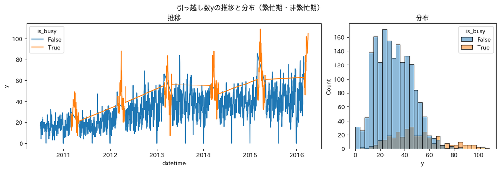

```python
# 繁忙期を抜き出して見てみる
train = train.with_columns(
    (
        ((pl.col("datetime").dt.month() == 3) | (pl.col("datetime").dt.month() == 4))
    ).alias("is_busy")
)

fig, axes = plt.subplots(
    nrows=1,
    ncols=2,
    height_ratios=[1],
    width_ratios=[2, 1],
    figsize=(12, 4),
    constrained_layout=True,
)
fig.suptitle("引っ越し数yの推移と分布（繁忙期・非繁忙期）")

axes[0].set_title("推移")
sns.lineplot(data=train, x="datetime", y="y", hue="is_busy", ax=axes[0])

axes[1].set_title("分布")
sns.histplot(data=train, x="y", hue="is_busy", ax=axes[1])

plt.show()
```

グラフについてのコメント

- 引越し数は緩やかに増加傾向。ビジネス的には喜ばしいが、未来の需要予測というタスクにおいては注意が必要
  - 機械学習モデルは訓練データとテストデータの目的変数の分布が等しいことを前提としているため、これが変化すると上手く予測できない
  - 例えば、2011年データをそのまま学習させて2012年の引越し数を予測すると、予測値は実際よりも小さく見積もられてしまうものと予想される
  - この緩やかな増加傾向を別モデルで捉えてやり、その差分を機械学習モデルに学習させるのが良いだろう
- 繁忙期(3~4月)は他の時期と比べて明確に異なりそう(大きなピークとなっている)
- 引っ越し数yが0の日がある
- yの分布は非対称 → 数値変換すると良いかも？

```python
# TODO: ここらへんで一度、ydata-profillingでレポートも出力させておく？ライブラリのインストールが必要。ipywigetsも必要。
# import pandas as pd
# from ydata_profiling import ProfileReport
# data_train = pd.read_csv('titanic_train.csv')
# profile = ProfileReport(data_train, title="Profiling Report")
# profile.to_widgets()
```

# 時間軸をどこで区切るべきか(年？年度？)

```python
# 年ごとで分けるか？年度ごとで分けるか？
train = train.with_columns(
    [
        pl.col("datetime").dt.year().alias("year"),
        pl.when(pl.col("datetime").dt.month() <= 3)
        .then(pl.col("datetime").dt.year() - 1)
        .otherwise(pl.col("datetime").dt.year())
        .alias("fy"),
    ]
)
print(train.head(3))
```

```
shape: (3, 10)
┌────────────┬────────────┬─────┬────────┬───────┬──────────┬──────────┬─────────┬──────┬──────┐
│ id         ┆ datetime   ┆ y   ┆ client ┆ close ┆ price_am ┆ price_pm ┆ is_busy ┆ year ┆ fy   │
│ ---        ┆ ---        ┆ --- ┆ ---    ┆ ---   ┆ ---      ┆ ---      ┆ ---     ┆ ---  ┆ ---  │
│ str        ┆ date       ┆ i64 ┆ i64    ┆ i64   ┆ i64      ┆ i64      ┆ bool    ┆ i32  ┆ i32  │
╞════════════╪════════════╪═════╪════════╪═══════╪══════════╪══════════╪═════════╪══════╪══════╡
│ 2010-07-01 ┆ 2010-07-01 ┆ 17  ┆ 0      ┆ 0     ┆ -1       ┆ -1       ┆ false   ┆ 2010 ┆ 2010 │
│ 2010-07-02 ┆ 2010-07-02 ┆ 18  ┆ 0      ┆ 0     ┆ -1       ┆ -1       ┆ false   ┆ 2010 ┆ 2010 │
│ 2010-07-03 ┆ 2010-07-03 ┆ 20  ┆ 0      ┆ 0     ┆ -1       ┆ -1       ┆ false   ┆ 2010 ┆ 2010 │
└────────────┴────────────┴─────┴────────┴───────┴──────────┴──────────┴─────────┴──────┴──────┘
```

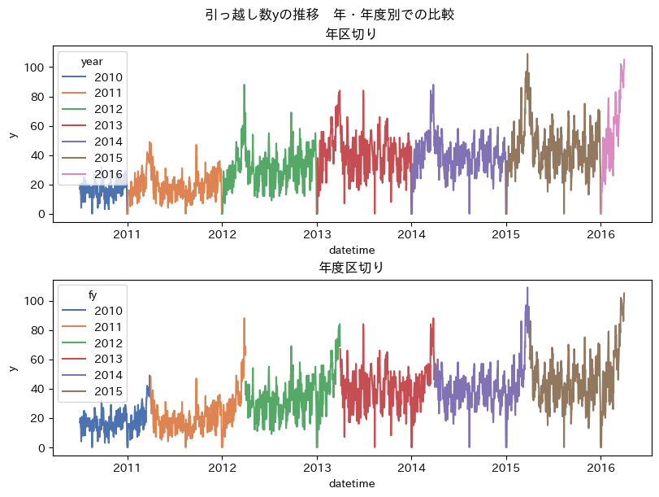

```python
fig, axes = plt.subplots(
    nrows=2,
    ncols=1,
    height_ratios=[1, 1],
    width_ratios=[1],
    figsize=(8, 6),
    constrained_layout=True,
)
fig.suptitle("引っ越し数yの推移　年・年度別での比較")

axes[0].set_title("年区切り")
sns.lineplot(data=train, x="datetime", y="y", hue="year", palette="deep", ax=axes[0])

axes[1].set_title("年度区切り")
sns.lineplot(data=train, x="datetime", y="y", hue="fy", palette="deep", ax=axes[1])

plt.show()
```

グラフへのコメント

- 年度で分けると、繁忙期(3~4月)のピークが分割されてしまい分析が難しくなってしまう。そのため、年ごとで分けるのが適切かと

# 引っ越し件数0の部分(→休業日と判明)

```python
# y==0、close==1のデータを抽出。引っ越し件数が0件または休業日の場合
with pl.Config(tbl_rows=-1):
    print("train\n", train.filter((pl.col("y") == 0) | (pl.col("close") == 1)))
```

```
train
 shape: (29, 10)
┌────────────┬────────────┬─────┬────────┬───────┬──────────┬──────────┬─────────┬──────┬──────┐
│ id         ┆ datetime   ┆ y   ┆ client ┆ close ┆ price_am ┆ price_pm ┆ is_busy ┆ year ┆ fy   │
│ ---        ┆ ---        ┆ --- ┆ ---    ┆ ---   ┆ ---      ┆ ---      ┆ ---     ┆ ---  ┆ ---  │
│ str        ┆ date       ┆ i64 ┆ i64    ┆ i64   ┆ i64      ┆ i64      ┆ bool    ┆ i32  ┆ i32  │
╞════════════╪════════════╪═════╪════════╪═══════╪══════════╪══════════╪═════════╪══════╪══════╡
│ 2010-08-18 ┆ 2010-08-18 ┆ 0   ┆ 0      ┆ 0     ┆ -1       ┆ -1       ┆ false   ┆ 2010 ┆ 2010 │
│ 2010-12-31 ┆ 2010-12-31 ┆ 0   ┆ 0      ┆ 1     ┆ -1       ┆ -1       ┆ false   ┆ 2010 ┆ 2010 │
│ 2011-01-01 ┆ 2011-01-01 ┆ 0   ┆ 0      ┆ 1     ┆ -1       ┆ -1       ┆ false   ┆ 2011 ┆ 2010 │
│ 2011-01-02 ┆ 2011-01-02 ┆ 0   ┆ 0      ┆ 1     ┆ -1       ┆ -1       ┆ false   ┆ 2011 ┆ 2010 │
│ 2011-01-03 ┆ 2011-01-03 ┆ 0   ┆ 0      ┆ 1     ┆ -1       ┆ -1       ┆ false   ┆ 2011 ┆ 2010 │
│ 2011-08-14 ┆ 2011-08-14 ┆ 0   ┆ 0      ┆ 0     ┆ 0        ┆ 0        ┆ false   ┆ 2011 ┆ 2011 │
│ 2011-12-31 ┆ 2011-12-31 ┆ 0   ┆ 0      ┆ 1     ┆ -1       ┆ -1       ┆ false   ┆ 2011 ┆ 2011 │
│ 2012-01-01 ┆ 2012-01-01 ┆ 0   ┆ 0      ┆ 1     ┆ -1       ┆ -1       ┆ false   ┆ 2012 ┆ 2011 │
│ 2012-01-02 ┆ 2012-01-02 ┆ 0   ┆ 0      ┆ 1     ┆ -1       ┆ -1       ┆ false   ┆ 2012 ┆ 2011 │
│ 2012-01-03 ┆ 2012-01-03 ┆ 0   ┆ 0      ┆ 1     ┆ -1       ┆ -1       ┆ false   ┆ 2012 ┆ 2011 │
│ 2012-12-31 ┆ 2012-12-31 ┆ 0   ┆ 0      ┆ 1     ┆ -1       ┆ -1       ┆ false   ┆ 2012 ┆ 2012 │
│ 2013-01-01 ┆ 2013-01-01 ┆ 0   ┆ 0      ┆ 1     ┆ -1       ┆ -1       ┆ false   ┆ 2013 ┆ 2012 │
│ 2013-01-02 ┆ 2013-01-02 ┆ 0   ┆ 0      ┆ 1     ┆ -1       ┆ -1       ┆ false   ┆ 2013 ┆ 2012 │
│ 2013-01-03 ┆ 2013-01-03 ┆ 0   ┆ 0      ┆ 1     ┆ -1       ┆ -1       ┆ false   ┆ 2013 ┆ 2012 │
│ 2013-08-12 ┆ 2013-08-12 ┆ 0   ┆ 0      ┆ 1     ┆ -1       ┆ -1       ┆ false   ┆ 2013 ┆ 2013 │
│ 2013-12-31 ┆ 2013-12-31 ┆ 0   ┆ 0      ┆ 1     ┆ -1       ┆ -1       ┆ false   ┆ 2013 ┆ 2013 │
│ 2014-01-01 ┆ 2014-01-01 ┆ 0   ┆ 0      ┆ 1     ┆ -1       ┆ -1       ┆ false   ┆ 2014 ┆ 2013 │
│ 2014-01-02 ┆ 2014-01-02 ┆ 0   ┆ 0      ┆ 1     ┆ -1       ┆ -1       ┆ false   ┆ 2014 ┆ 2013 │
│ 2014-01-03 ┆ 2014-01-03 ┆ 0   ┆ 0      ┆ 1     ┆ -1       ┆ -1       ┆ false   ┆ 2014 ┆ 2013 │
│ 2014-08-12 ┆ 2014-08-12 ┆ 0   ┆ 0      ┆ 1     ┆ -1       ┆ -1       ┆ false   ┆ 2014 ┆ 2014 │
│ 2014-12-31 ┆ 2014-12-31 ┆ 0   ┆ 0      ┆ 1     ┆ -1       ┆ -1       ┆ false   ┆ 2014 ┆ 2014 │
│ 2015-01-01 ┆ 2015-01-01 ┆ 0   ┆ 0      ┆ 1     ┆ -1       ┆ -1       ┆ false   ┆ 2015 ┆ 2014 │
│ 2015-01-02 ┆ 2015-01-02 ┆ 0   ┆ 0      ┆ 1     ┆ -1       ┆ -1       ┆ false   ┆ 2015 ┆ 2014 │
│ 2015-01-03 ┆ 2015-01-03 ┆ 0   ┆ 0      ┆ 1     ┆ -1       ┆ -1       ┆ false   ┆ 2015 ┆ 2014 │
│ 2015-08-12 ┆ 2015-08-12 ┆ 0   ┆ 0      ┆ 1     ┆ -1       ┆ -1       ┆ false   ┆ 2015 ┆ 2015 │
│ 2015-12-31 ┆ 2015-12-31 ┆ 0   ┆ 0      ┆ 1     ┆ -1       ┆ -1       ┆ false   ┆ 2015 ┆ 2015 │
│ 2016-01-01 ┆ 2016-01-01 ┆ 0   ┆ 0      ┆ 1     ┆ -1       ┆ -1       ┆ false   ┆ 2016 ┆ 2015 │
│ 2016-01-02 ┆ 2016-01-02 ┆ 0   ┆ 0      ┆ 1     ┆ -1       ┆ -1       ┆ false   ┆ 2016 ┆ 2015 │
│ 2016-01-03 ┆ 2016-01-03 ┆ 0   ┆ 0      ┆ 1     ┆ -1       ┆ -1       ┆ false   ┆ 2016 ┆ 2015 │
└────────────┴────────────┴─────┴────────┴───────┴──────────┴──────────┴─────────┴──────┴──────┘
```

y=0の部分についてのコメント

休業日の場合についてのコメント

```python
# 休業日の場合は引っ越し数0。これはルールベースで予測することとする。そのため学習からは除外

# trainからpl.col("y"==0)である部分を除外する
# 2010-08-18と2011-08-14はお盆であるものの休業日に設定されていなかったが、
# 以降の年では休業日に設定されたみたいなので学習からは取り除いておく
train = train.filter(
    (pl.col("close") != 1)
    & (pl.col("id") != "2010-08-18")
    & (pl.col("id") != "2011-08-14")
)

# test_close: testデータの中で休業日の部分(pl.col("close"==1))を抜き出し、
# その日は引っ越し数0(pl.col("y"==0))であるとしたdataframe
# 元のtestからはその部分は取り除いておく
test_close = test.filter(pl.col("close") == 1)[["id"]]
test_close = test_close.with_columns(pl.Series("y", [0.0] * len(test_close)))
test = test.filter(pl.col("close") != 1)

# ちゃんと休業日関連が消せているか確認
with pl.Config(tbl_rows=-1):
    print("train\n", train.filter((pl.col("y") == 0) | (pl.col("close") == 1)))
    print("test\n", test.filter((pl.col("close") == 1)))
```

```
train
 shape: (0, 10)
┌─────┬──────────┬─────┬────────┬───────┬──────────┬──────────┬─────────┬──────┬─────┐
│ id  ┆ datetime ┆ y   ┆ client ┆ close ┆ price_am ┆ price_pm ┆ is_busy ┆ year ┆ fy  │
│ --- ┆ ---      ┆ --- ┆ ---    ┆ ---   ┆ ---      ┆ ---      ┆ ---     ┆ ---  ┆ --- │
│ str ┆ date     ┆ i64 ┆ i64    ┆ i64   ┆ i64      ┆ i64      ┆ bool    ┆ i32  ┆ i32 │
╞═════╪══════════╪═════╪════════╪═══════╪══════════╪══════════╪═════════╪══════╪═════╡
└─────┴──────────┴─────┴────────┴───────┴──────────┴──────────┴─────────┴──────┴─────┘
test
 shape: (0, 6)
┌─────┬──────────┬────────┬───────┬──────────┬──────────┐
│ id  ┆ datetime ┆ client ┆ close ┆ price_am ┆ price_pm │
│ --- ┆ ---      ┆ ---    ┆ ---   ┆ ---      ┆ ---      │
│ str ┆ date     ┆ i64    ┆ i64   ┆ i64      ┆ i64      │
╞═════╪══════════╪════════╪═══════╪══════════╪══════════╡
└─────┴──────────┴────────┴───────┴──────────┴──────────┘
```

```python
# 分離が済んだので、close列は削除
train = train.drop("close")
test = test.drop("close")
```

# clientフラグについて

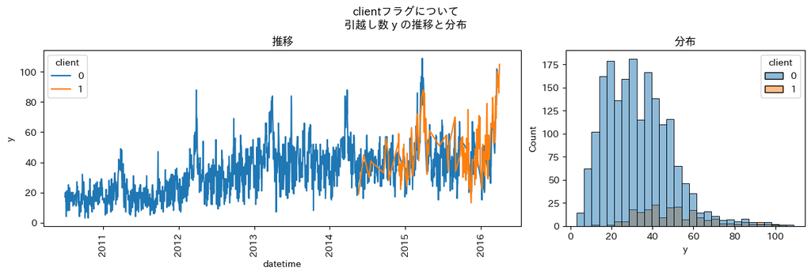

```
shape: (206, 9)
┌────────────┬────────────┬─────┬────────┬──────────┬──────────┬─────────┬──────┬──────┐
│ id         ┆ datetime   ┆ y   ┆ client ┆ price_am ┆ price_pm ┆ is_busy ┆ year ┆ fy   │
│ ---        ┆ ---        ┆ --- ┆ ---    ┆ ---      ┆ ---      ┆ ---     ┆ ---  ┆ ---  │
│ str        ┆ date       ┆ i64 ┆ i64    ┆ i64      ┆ i64      ┆ bool    ┆ i32  ┆ i32  │
╞════════════╪════════════╪═════╪════════╪══════════╪══════════╪═════════╪══════╪══════╡
│ 2014-05-20 ┆ 2014-05-20 ┆ 19  ┆ 1      ┆ 0        ┆ 0        ┆ false   ┆ 2014 ┆ 2014 │
│ 2014-06-14 ┆ 2014-06-14 ┆ 45  ┆ 1      ┆ 1        ┆ 1        ┆ false   ┆ 2014 ┆ 2014 │
│ 2014-07-10 ┆ 2014-07-10 ┆ 30  ┆ 1      ┆ 0        ┆ 0        ┆ false   ┆ 2014 ┆ 2014 │
│ 2014-07-19 ┆ 2014-07-19 ┆ 41  ┆ 1      ┆ 2        ┆ 1        ┆ false   ┆ 2014 ┆ 2014 │
│ 2014-07-23 ┆ 2014-07-23 ┆ 40  ┆ 1      ┆ 0        ┆ 0        ┆ false   ┆ 2014 ┆ 2014 │
│ …          ┆ …          ┆ …   ┆ …      ┆ …        ┆ …        ┆ …       ┆ …    ┆ …    │
│ 2016-03-27 ┆ 2016-03-27 ┆ 94  ┆ 1      ┆ 5        ┆ 4        ┆ true    ┆ 2016 ┆ 2015 │
│ 2016-03-28 ┆ 2016-03-28 ┆ 86  ┆ 1      ┆ 4        ┆ 4        ┆ true    ┆ 2016 ┆ 2015 │
│ 2016-03-29 ┆ 2016-03-29 ┆ 98  ┆ 1      ┆ 4        ┆ 4        ┆ true    ┆ 2016 ┆ 2015 │
│ 2016-03-30 ┆ 2016-03-30 ┆ 99  ┆ 1      ┆ 5        ┆ 4        ┆ true    ┆ 2016 ┆ 2015 │
│ 2016-03-31 ┆ 2016-03-31 ┆ 105 ┆ 1      ┆ 5        ┆ 4        ┆ true    ┆ 2016 ┆ 2015 │
└────────────┴────────────┴─────┴────────┴──────────┴──────────┴─────────┴──────┴──────┘
```

```python
fig, axes = plt.subplots(
    nrows=1,
    ncols=2,
    height_ratios=[1],
    width_ratios=[2, 1],
    figsize=(12, 4),
    constrained_layout=True,
)
plt.suptitle("clientフラグについて\n引越し数 y の推移と分布")

axes[0].set_title("推移")
axes[0].tick_params(axis="x", rotation=90)
sns.histplot(data=train, x="y", hue="client", ax=axes[1])

axes[1].set_title("分布")
sns.lineplot(data=train, x="datetime", y="y", hue="client", ax=axes[0])

plt.show()
print(train.filter(pl.col("client") == 1))
```

2014年5月からclient(法人が絡む特殊な引越し日フラグ)に関する何かが始まっているみたい  
それが何のことなのかは良くわからんけど…日にちに対してフラグが立っている  
→多分、「この日は法人からの依頼があった」ということ？yの内何件がそれだったのかはわからんけど⋯

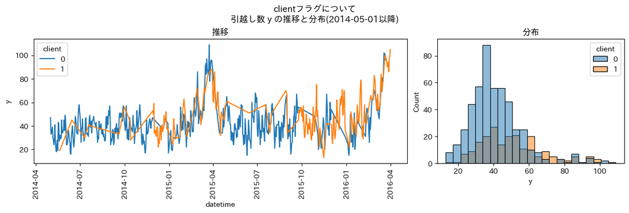

```
client=1(法人あり)のときの引っ越し数yの平均 50.58
client=0(通常時)のときの引っ越し数yの平均 41.26
```

```python
# 期間を絞り込んで表示。
fig, axes = plt.subplots(
    nrows=1,
    ncols=2,
    height_ratios=[1],
    width_ratios=[2, 1],
    figsize=(12, 4),
    constrained_layout=True,
)
plt.suptitle("clientフラグについて\n引越し数 y の推移と分布(2014-05-01以降)")

axes[0].set_title("推移")
axes[0].tick_params(axis="x", rotation=90)
sns.histplot(
    data=train.filter(pl.col("datetime") >= date(2014, 5, 1)),
    x="y",
    hue="client",
    ax=axes[1],
)

axes[1].set_title("分布")
sns.lineplot(
    data=train.filter(pl.col("datetime") >= date(2014, 5, 1)),
    x="datetime",
    y="y",
    hue="client",
    ax=axes[0],
)

plt.show()

print(
    "client=1(法人あり)のときの引っ越し数yの平均",
    np.round(
        train.filter(pl.col("datetime") >= date(2014, 5, 1))
        .filter(pl.col("client") == 1)["y"]
        .mean(),
        decimals=2,
    ),
)
print(
    "client=0(通常時)のときの引っ越し数yの平均",
    np.round(
        train.filter(pl.col("datetime") >= date(2014, 5, 1))
        .filter(pl.col("client") == 0)["y"]
        .mean(),
        decimals=2,
    ),
)
```

client=1のときは、そうでないときと比べて引っ越し数が通常より多めの傾向になっている  
とはいえそこまで顕著ではないようにも思うが…

# 料金区分(午前、午後)

```python
graph_color = px.colors.sequential.Magma_r
# https://oeconomicus.jp/2021/07/plotly-color-scale/

# pandas 化
df = train.to_pandas().copy()

# すべてのカテゴリ（午前/午後の和集合）で色を固定
cats_all = sorted(set(df["price_am"].unique()) | set(df["price_pm"].unique()))
colors = graph_color[: len(cats_all)]
# Plotlyのcolor_discrete_mapはキーが文字列比較になることが多いので安全のため文字列化
color_map = {str(c): colors[i] for i, c in enumerate(cats_all)}

# 描画用に文字列列を用意（凡例名/trace.nameの一致を安定させる）
df["price_am_str"] = df["price_am"].astype(str)
df["price_pm_str"] = df["price_pm"].astype(str)

# 大枠（2行×2列）
fig = make_subplots(
    rows=2,
    cols=2,
    row_heights=[0.5, 0.5],
    column_widths=[0.7, 0.3],
    vertical_spacing=0.15,
    horizontal_spacing=0.05,
    subplot_titles=("午前: 推移", "午前: 分布", "午後: 推移", "午後: 分布"),
)

fig.update_layout(
    width=1500,
    height=900,
    title_text="午前/午後 料金区分別<br>引越し数 y の推移と分布",
    showlegend=True,
    legend_tracegroupgap=12,
)


# 指定された行に対して、左に推移(scatter)、右に分布(histogram)を追加する関数
def add_section(colname_str: str, row: int):
    # 左：推移（scatter）
    scatter_fig = px.scatter(
        df,
        x="datetime",
        y="y",
        color=colname_str,
        category_orders={colname_str: [str(c) for c in cats_all]},
        color_discrete_map=color_map,
    )
    for tr in scatter_fig.data:
        # カテゴリごとに legendgroup を統一
        tr.legendgroup = tr.name  # カテゴリ単位のグループ化
        # tr.marker.symbol = "cross"               # マーカー形状を変更 https://plotly.com/python/marker-style/
        tr.showlegend = row == 1  # 凡例は上段のみ表示
        fig.add_trace(tr, row=row, col=1)

    # 右：分布（histogram）
    hist_fig = px.histogram(
        df,
        x="y",
        color=colname_str,
        category_orders={colname_str: [str(c) for c in cats_all]},
        color_discrete_map=color_map,
    )
    for tr in hist_fig.data:
        tr.legendgroup = tr.name  # 同じカテゴリ名でグルーピング
        tr.showlegend = False  # 凡例は出さないが連動はする
        fig.add_trace(tr, row=row, col=2)

    # 軸ラベル
    fig.update_xaxes(title_text="datetime", row=row, col=1)
    fig.update_yaxes(title_text="y", row=row, col=1)
    fig.update_xaxes(title_text="y", row=row, col=2)
    fig.update_yaxes(title_text="count", row=row, col=2)


# 上段: 午前
add_section("price_am_str", row=1)
# 下段: 午後
add_section("price_pm_str", row=2)

fig.show()

del df, cats_all, colors, color_map
```

[interactive chart not shown]

-1は欠損。0~5で数値が高いほど料金が高い  
グラフより、yが小さいところは料金を低くしており、yが高いところは料金が高くなっていることが分かる  
説明通り、繁忙期は料金を高くして調整しようとしていることが見て取れる  
所々、料金設定ミスっているところもある？(料金設定高めなのにy低め)  
あと、2010年の料金区分のデータが欠損している？

```python
print("2010年のデータ数", len(train.filter(pl.col("datetime") <= date(2010, 12, 31))))
print(
    "2010年でprice_am=-1(欠損)となっているデータ数",
    len(
        (train.filter(pl.col("datetime") <= date(2010, 12, 31))).filter(
            pl.col("price_am") == -1
        )
    ),
)
print(
    "2010年でprice_pm=-1(欠損)となっているデータ数",
    len(
        (train.filter(pl.col("datetime") <= date(2010, 12, 31))).filter(
            pl.col("price_pm") == -1
        )
    ),
)
```

```
2010年のデータ数 182
2010年でprice_am=-1(欠損)となっているデータ数 182
2010年でprice_pm=-1(欠損)となっているデータ数 182
```

2010年のデータは料金設定という大事なデータが欠損しているため、学習からは外すべし

## 料金区分price_am, price_pmが3以上のものを詳しく見てみる

```python
# 料金区分price_am, price_pmが3以上のものを詳しく見てみる
# そこまで数は多くなさそうなので全件表示
with pl.Config(tbl_rows=-1):
    print(train.filter((pl.col("price_am") >= 3) | (pl.col("price_pm") >= 3)))
```

```
shape: (114, 9)
┌────────────┬────────────┬─────┬────────┬──────────┬──────────┬─────────┬──────┬──────┐
│ id         ┆ datetime   ┆ y   ┆ client ┆ price_am ┆ price_pm ┆ is_busy ┆ year ┆ fy   │
│ ---        ┆ ---        ┆ --- ┆ ---    ┆ ---      ┆ ---      ┆ ---     ┆ ---  ┆ ---  │
│ str        ┆ date       ┆ i64 ┆ i64    ┆ i64      ┆ i64      ┆ bool    ┆ i32  ┆ i32  │
╞════════════╪════════════╪═════╪════════╪══════════╪══════════╪═════════╪══════╪══════╡
│ 2011-02-26 ┆ 2011-02-26 ┆ 32  ┆ 0      ┆ 3        ┆ 2        ┆ false   ┆ 2011 ┆ 2010 │
│ 2011-03-19 ┆ 2011-03-19 ┆ 40  ┆ 0      ┆ 3        ┆ 3        ┆ true    ┆ 2011 ┆ 2010 │
│ 2011-03-20 ┆ 2011-03-20 ┆ 41  ┆ 0      ┆ 5        ┆ 3        ┆ true    ┆ 2011 ┆ 2010 │
│ 2011-03-21 ┆ 2011-03-21 ┆ 39  ┆ 0      ┆ 3        ┆ 2        ┆ true    ┆ 2011 ┆ 2010 │
│ 2011-03-22 ┆ 2011-03-22 ┆ 39  ┆ 0      ┆ 3        ┆ 3        ┆ true    ┆ 2011 ┆ 2010 │
│ 2011-03-23 ┆ 2011-03-23 ┆ 37  ┆ 0      ┆ 5        ┆ 4        ┆ true    ┆ 2011 ┆ 2010 │
│ 2011-03-24 ┆ 2011-03-24 ┆ 36  ┆ 0      ┆ 5        ┆ 3        ┆ true    ┆ 2011 ┆ 2010 │
│ 2011-03-25 ┆ 2011-03-25 ┆ 35  ┆ 0      ┆ 4        ┆ 5        ┆ true    ┆ 2011 ┆ 2010 │
│ 2011-03-26 ┆ 2011-03-26 ┆ 40  ┆ 0      ┆ 5        ┆ 5        ┆ true    ┆ 2011 ┆ 2010 │
│ 2011-03-27 ┆ 2011-03-27 ┆ 35  ┆ 0      ┆ 5        ┆ 4        ┆ true    ┆ 2011 ┆ 2010 │
│ 2011-03-28 ┆ 2011-03-28 ┆ 49  ┆ 0      ┆ 3        ┆ 2        ┆ true    ┆ 2011 ┆ 2010 │
│ 2011-03-29 ┆ 2011-03-29 ┆ 37  ┆ 0      ┆ 3        ┆ 2        ┆ true    ┆ 2011 ┆ 2010 │
│ 2011-03-30 ┆ 2011-03-30 ┆ 38  ┆ 0      ┆ 4        ┆ 3        ┆ true    ┆ 2011 ┆ 2010 │
│ 2011-03-31 ┆ 2011-03-31 ┆ 34  ┆ 0      ┆ 4        ┆ 4        ┆ true    ┆ 2011 ┆ 2010 │
│ 2011-04-01 ┆ 2011-04-01 ┆ 48  ┆ 0      ┆ 4        ┆ 2        ┆ true    ┆ 2011 ┆ 2011 │
│ 2011-04-02 ┆ 2011-04-02 ┆ 29  ┆ 0      ┆ 5        ┆ 4        ┆ true    ┆ 2011 ┆ 2011 │
│ 2011-04-03 ┆ 2011-04-03 ┆ 28  ┆ 0      ┆ 3        ┆ 3        ┆ true    ┆ 2011 ┆ 2011 │
│ 2011-04-09 ┆ 2011-04-09 ┆ 39  ┆ 0      ┆ 3        ┆ 2        ┆ true    ┆ 2011 ┆ 2011 │
│ 2011-04-23 ┆ 2011-04-23 ┆ 26  ┆ 0      ┆ 3        ┆ 2        ┆ true    ┆ 2011 ┆ 2011 │
│ 2011-04-30 ┆ 2011-04-30 ┆ 21  ┆ 0      ┆ 3        ┆ 3        ┆ true    ┆ 2011 ┆ 2011 │
│ 2011-12-30 ┆ 2011-12-30 ┆ 15  ┆ 0      ┆ 1        ┆ 3        ┆ false   ┆ 2011 ┆ 2011 │
│ 2012-02-25 ┆ 2012-02-25 ┆ 49  ┆ 0      ┆ 3        ┆ 2        ┆ false   ┆ 2012 ┆ 2011 │
│ 2012-03-17 ┆ 2012-03-17 ┆ 58  ┆ 0      ┆ 3        ┆ 3        ┆ true    ┆ 2012 ┆ 2011 │
│ 2012-03-18 ┆ 2012-03-18 ┆ 45  ┆ 0      ┆ 3        ┆ 2        ┆ true    ┆ 2012 ┆ 2011 │
│ 2012-03-20 ┆ 2012-03-20 ┆ 51  ┆ 0      ┆ 3        ┆ 2        ┆ true    ┆ 2012 ┆ 2011 │
│ 2012-03-22 ┆ 2012-03-22 ┆ 49  ┆ 0      ┆ 3        ┆ 2        ┆ true    ┆ 2012 ┆ 2011 │
│ 2012-03-23 ┆ 2012-03-23 ┆ 47  ┆ 0      ┆ 4        ┆ 3        ┆ true    ┆ 2012 ┆ 2011 │
│ 2012-03-24 ┆ 2012-03-24 ┆ 55  ┆ 0      ┆ 5        ┆ 4        ┆ true    ┆ 2012 ┆ 2011 │
│ 2012-03-25 ┆ 2012-03-25 ┆ 49  ┆ 0      ┆ 4        ┆ 5        ┆ true    ┆ 2012 ┆ 2011 │
│ 2012-03-26 ┆ 2012-03-26 ┆ 69  ┆ 0      ┆ 3        ┆ 2        ┆ true    ┆ 2012 ┆ 2011 │
│ 2012-03-27 ┆ 2012-03-27 ┆ 88  ┆ 0      ┆ 3        ┆ 2        ┆ true    ┆ 2012 ┆ 2011 │
│ 2012-03-29 ┆ 2012-03-29 ┆ 63  ┆ 0      ┆ 4        ┆ 2        ┆ true    ┆ 2012 ┆ 2011 │
│ 2012-03-30 ┆ 2012-03-30 ┆ 69  ┆ 0      ┆ 4        ┆ 4        ┆ true    ┆ 2012 ┆ 2011 │
│ 2012-03-31 ┆ 2012-03-31 ┆ 63  ┆ 0      ┆ 5        ┆ 5        ┆ true    ┆ 2012 ┆ 2011 │
```

[output cut: 66 more lines]

```
│ 2016-03-18 ┆ 2016-03-18 ┆ 102 ┆ 0      ┆ 2        ┆ 3        ┆ true    ┆ 2016 ┆ 2015 │
│ 2016-03-19 ┆ 2016-03-19 ┆ 94  ┆ 1      ┆ 3        ┆ 3        ┆ true    ┆ 2016 ┆ 2015 │
│ 2016-03-20 ┆ 2016-03-20 ┆ 101 ┆ 0      ┆ 4        ┆ 4        ┆ true    ┆ 2016 ┆ 2015 │
│ 2016-03-21 ┆ 2016-03-21 ┆ 100 ┆ 1      ┆ 3        ┆ 3        ┆ true    ┆ 2016 ┆ 2015 │
│ 2016-03-22 ┆ 2016-03-22 ┆ 96  ┆ 0      ┆ 4        ┆ 4        ┆ true    ┆ 2016 ┆ 2015 │
│ 2016-03-23 ┆ 2016-03-23 ┆ 96  ┆ 1      ┆ 2        ┆ 4        ┆ true    ┆ 2016 ┆ 2015 │
│ 2016-03-24 ┆ 2016-03-24 ┆ 94  ┆ 1      ┆ 3        ┆ 2        ┆ true    ┆ 2016 ┆ 2015 │
│ 2016-03-25 ┆ 2016-03-25 ┆ 90  ┆ 1      ┆ 4        ┆ 5        ┆ true    ┆ 2016 ┆ 2015 │
│ 2016-03-26 ┆ 2016-03-26 ┆ 93  ┆ 1      ┆ 5        ┆ 5        ┆ true    ┆ 2016 ┆ 2015 │
│ 2016-03-27 ┆ 2016-03-27 ┆ 94  ┆ 1      ┆ 5        ┆ 4        ┆ true    ┆ 2016 ┆ 2015 │
│ 2016-03-28 ┆ 2016-03-28 ┆ 86  ┆ 1      ┆ 4        ┆ 4        ┆ true    ┆ 2016 ┆ 2015 │
│ 2016-03-29 ┆ 2016-03-29 ┆ 98  ┆ 1      ┆ 4        ┆ 4        ┆ true    ┆ 2016 ┆ 2015 │
│ 2016-03-30 ┆ 2016-03-30 ┆ 99  ┆ 1      ┆ 5        ┆ 4        ┆ true    ┆ 2016 ┆ 2015 │
│ 2016-03-31 ┆ 2016-03-31 ┆ 105 ┆ 1      ┆ 5        ┆ 4        ┆ true    ┆ 2016 ┆ 2015 │
└────────────┴────────────┴─────┴────────┴──────────┴──────────┴─────────┴──────┴──────┘
```

3月、4月に高めの料金設定をしていることが見て取れる

# トレンドを捉える(prophet)

```python
# 年を経るごとにyが上昇していくため、yの分布がどんどん右にシフトしていく問題に対処したい
# そこで、prophetによる時系列予測によってyのトレンドを予測し、yのトレンドを除去する

# polarsのdatetime型をpandasのdatetime型に変換する必要がある
## 訓練データ
train_pandas = (
    train.select(["datetime", "y"])
    .rename({"datetime": "ds", "y": "y"})
    .to_pandas()
    .copy()
)
## テストデータ。datetimeカラムを渡すだけ
test_pandas = test.select(["datetime"]).rename({"datetime": "ds"}).to_pandas().copy()

# 学習。prophetでは年を超えた全体的なトレンドだけを捉えたいので、seasonalityは全てFalseにする
model = Prophet(
    yearly_seasonality=False,
    weekly_seasonality=False,
    daily_seasonality=False,
    seasonality_mode="additive",
)
model.fit(train_pandas)

# 予測
# グラフ描画用
forecast_train = model.predict(train_pandas)
forecast_test = model.predict(test_pandas)

# 元データへの結合用
forecast_train_pl = pl.Series("y_trend", model.predict(train_pandas)["yhat"].values)

# trainの方にjoinして列追加
train = train.with_columns(forecast_train_pl)
```

```
15:44:11 - cmdstanpy - INFO - Chain [1] start processing
15:44:12 - cmdstanpy - INFO - Chain [1] done processing
```

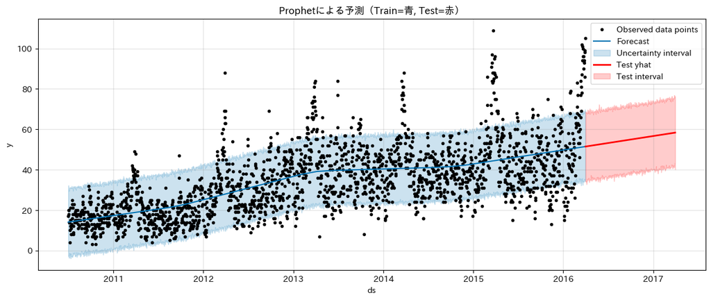

```python
# 予測結果の可視化
fig, ax = plt.subplots(
    figsize=(12, 5),
    constrained_layout=True,
)
ax.set_title("Prophetによる予測（Train=青, Test=赤）")

# train側は Prophet の標準描画（青・点群付き）
model.plot(model.predict(train_pandas), ax=ax)

# test側は後から重ね描き（赤）
ax.plot(
    forecast_test["ds"],
    forecast_test["yhat"],
    color="red",
    linewidth=2,
    label="Test yhat",
)
ax.fill_between(
    forecast_test["ds"],
    forecast_test["yhat_lower"],
    forecast_test["yhat_upper"],
    color="red",
    alpha=0.2,
    label="Test interval",
)

ax.legend()
plt.show()

# 後で再宣言しちゃいそうな変数はここで一度削除
del train_pandas, test_pandas, forecast_train, forecast_test, forecast_train_pl, model
```

コメント

- 全体的な上昇傾向が上手く捉えられている
- testデータの期間についても、尤もらしい傾向が出力できているように思う

## トレンドとの残差を確認

```python
# 残差列、曜日・月列を追加
train = train.with_columns(
    (pl.col("y") - pl.col("y_trend")).alias("y_resid"),
    pl.col("datetime").dt.weekday().alias("weekday"),
    pl.col("datetime").dt.month().alias("month"),
)
```

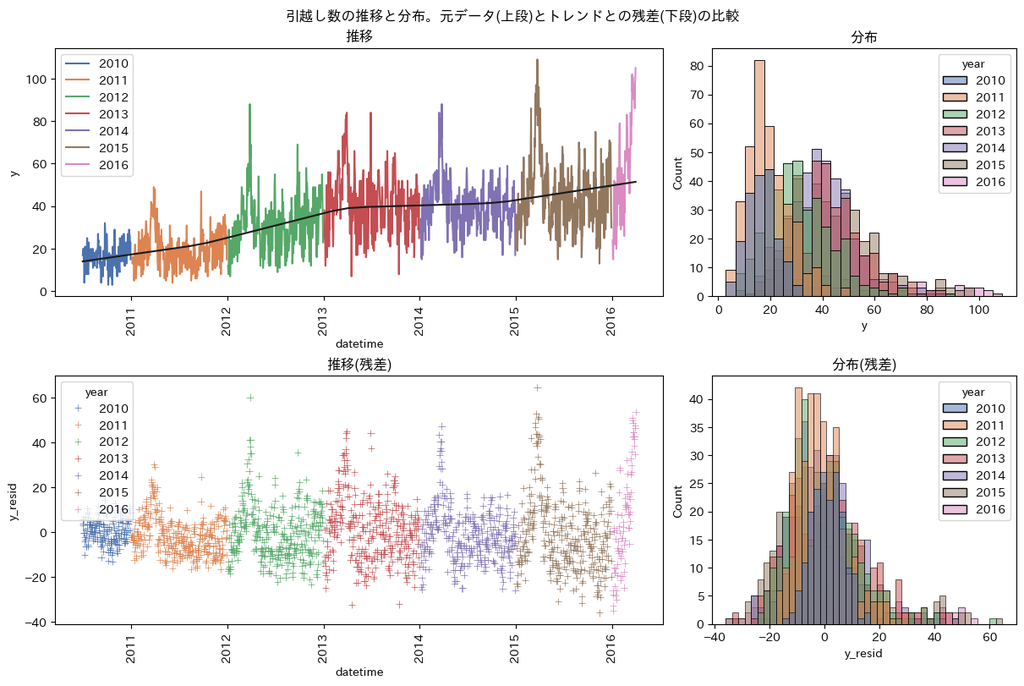

```python
# トレンドとの差分を取ることで、年ごとの分布のズレが解消されるか確認する

fig, axes = plt.subplots(
    nrows=2,
    ncols=2,
    height_ratios=[1, 1],
    width_ratios=[2, 1],
    figsize=(12, 8),
    constrained_layout=True,
)
fig.suptitle("引越し数の推移と分布。元データ(上段)とトレンドとの残差(下段)の比較")

# 上段。そのまま
axes[0, 0].set_title("推移")
axes[0, 0].tick_params(axis="x", rotation=90)
sns.lineplot(data=train, x="datetime", y="y", hue="year", palette="deep", ax=axes[0, 0])
sns.lineplot(data=train, x="datetime", y="y_trend", color="0.1", ax=axes[0, 0])

axes[0, 1].set_title("分布")
sns.histplot(data=train, x="y", hue="year", palette="deep", ax=axes[0, 1])

# 下段。差分
axes[1, 0].set_title("推移(残差)")
axes[1, 0].tick_params(axis="x", rotation=90)
sns.scatterplot(
    data=train,
    x="datetime",
    y="y_resid",
    hue="year",
    palette="deep",
    marker="+",
    ax=axes[1, 0],
)

axes[1, 1].set_title("分布(残差)")
sns.histplot(data=train, x="y_resid", hue="year", palette="deep", ax=axes[1, 1])

plt.show()
```

コメント

- 狙い通り、うまい具合に年ごとの分布の中心が揃った。

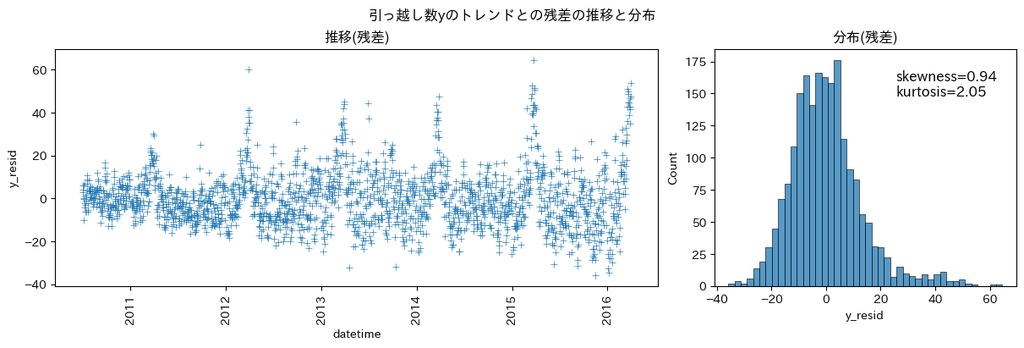

```python
# 全体としての分布がどう変わったかも確認
skew_resid = stats.skew(train["y_resid"])
kurt_resid = stats.kurtosis(train["y_resid"])

fig, axes = plt.subplots(
    nrows=1,
    ncols=2,
    height_ratios=[1],
    width_ratios=[2, 1],
    figsize=(12, 4),
    constrained_layout=True,
)
fig.suptitle("引っ越し数yのトレンドとの残差の推移と分布")

# 下段。差分
axes[0].set_title("推移(残差)")
axes[0].tick_params(axis="x", rotation=90)
sns.scatterplot(data=train, x="datetime", y="y_resid", marker="+", ax=axes[0])

axes[1].set_title("分布(残差)")
sns.histplot(data=train, x="y_resid", ax=axes[1])
axes[1].text(
    0.6,
    0.8,
    f"skewness={skew_resid:.2f}\nkurtosis={kurt_resid:.2f}",
    fontsize=12,
    transform=axes[1].transAxes,
)

plt.show()
```

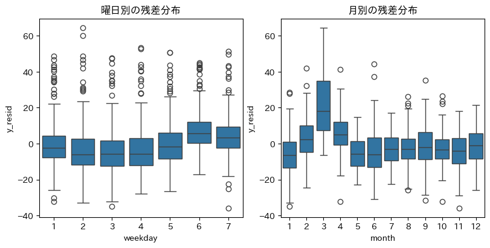

```python
# 曜日・月ごとの残差分布を確認
fig, axes = plt.subplots(
    nrows=1,
    ncols=2,
    height_ratios=[1],
    width_ratios=[1, 1],
    figsize=(8, 4),
    constrained_layout=True,
)
# fig.suptitle("")

axes[0].set_title("曜日別の残差分布")
sns.boxplot(x="weekday", y="y_resid", data=train, ax=axes[0])

axes[1].set_title("月別の残差分布")
sns.boxplot(x="month", y="y_resid", data=train, ax=axes[1])

plt.show()
```

コメント

- 火・水・木は受注減りがち。土日は受注多め
- 繁忙期である3~4月は確かに通常期よりも受注が多い